# 规格并不存在Specifications Don't Exist

Mike Dodds · Galois

2025 年 6 月 16 日June 16, 2025

https://www.galois.com/articles/specifications-dont-exist

*本文是[《向业界推广形式化方法，什么有效、什么无效》](https://www.galois.com/articles/what-works-and-doesnt-selling-formal-methods)的姊妹篇。它最初是[我在 2024 年末所作的一次演讲](https://mikedodds.github.io/files/talks/2024-10-09-n-things-I-learned.pdf)的一部分。**This article is a companion piece to* [*What Works (and Doesn't) Selling Formal Methods*](https://www.galois.com/articles/what-works-and-doesnt-selling-formal-methods)*. It began life as part of* [*a talk I gave in late 2024*](https://mikedodds.github.io/files/talks/2024-10-09-n-things-I-learned.pdf)*.*

有些事情很难，有些事情只是很贵。Some things are difficult, and some things are merely expensive.

想象一下：外星人要来杀光我们。人类派出最优秀的谈判代表，外星人宣布，只有我们在*一年之内*发布一个*经过形式化验证的 [GCC](https://gcc.gnu.org/) 版本*——每一行该死的代码都要验证……他们才会取消这场可怕的进攻。Imagine this: aliens are coming to kill us all. Humanity sends its best negotiators, and the aliens announce that they will call off their horrible assault only if we release a *formally verified version of* [*GCC*](https://gcc.gnu.org/), every damn line of code… in ONE YEAR.

在一阵可以理解的混乱之后，七国集团的领导人召来 [Xavier Leroy](https://en.wikipedia.org/wiki/Xavier_Leroy)，塞给他一张金额巨大的支票，让他赶紧开工。很快，世界各地一仓库一仓库的数学家开始日夜不停地证明 [Rocq](https://rocq-prover.org/) 定理。协调工作极其艰巨，但他们还是完成了！外星人回家了，Xavier 赢得了菲尔兹奖、艾美奖／格莱美奖／奥斯卡奖／托尼奖大满贯（EGOT），以及全部五项诺贝尔奖，<sup>1</sup>其他人则回去继续担心 AI。After some understandable confusion, the heads of the G7 summon [Xavier Leroy](https://en.wikipedia.org/wiki/Xavier_Leroy), hand him an enormous check, and tell him to get on with it. Pretty soon, warehouses of mathematicians around the world are proving [Rocq](https://rocq-prover.org/) theorems day and night. The coordination challenges are enormous, but they get it done! The aliens go home, Xavier wins a Fields medal, EGOT, and all five Nobel prizes,<sup>1</sup> and everyone else goes back to worrying about AI.

我要说的是，我们基本上知道怎样构建一个经过形式化验证的编译器——[我们已经做出来过了](https://compcert.org/)。经过形式化验证的[密码库](https://hacl-star.github.io/)、[解析器](https://project-everest.github.io/everparse/)和[微内核](https://sel4.systems/)也是如此。GCC 之所以还没有经过形式化验证，是因为这么做贵得离谱：收益不足以抵偿成本。不过，如果外星人*真的*来了，我敢打赌，完成这件事所花的钱，不会超过[漫威电影宇宙第三阶段](https://en.wikipedia.org/wiki/Marvel_Cinematic_Universe%3A_Phase_Three)的制作成本（22 亿至 24 亿美元）。The point I’m making is that we basically know how to build a formally verified compiler—[we already did it](https://compcert.org/). The same is true for formally verified [cryptographic libraries](https://hacl-star.github.io/), [parsers](https://project-everest.github.io/everparse/), and [microkernels](https://sel4.systems/). The reason that GCC hasn’t been formally verified is that to do so would be absurdly expensive. It wouldn’t be beneficial enough to justify the cost. But if aliens *do* show up, I bet we could do it for less than the cost of [MCU Phase 3](https://en.wikipedia.org/wiki/Marvel_Cinematic_Universe%3A_Phase_Three) ($2.2–2.4 billion).

好，换一个故事：外星人要来杀光我们，要求我们交出一个经过形式化验证的*网页浏览器*。Xavier 举起了手——这回大家把他也带来了——问道：呃……他们到底想要什么？比如说，从形式化的角度讲，网页浏览器究竟是什么？这个问题让外星人既困惑又愤怒！我们当然应该有 Chrome 的形式化规格，Chrome 不就是我们自己造的吗？嗯，然后人类就这么完了。Okay different story: aliens are coming to kill us all and they demand a formally verified *web browser*. Xavier sticks his hand up (they brought him this time) and asks, er… what is it exactly they want? Like, what formally is a web browser, anyway? This question confuses and infuriates the aliens! Surely we have a formal specification for Chrome, didn’t we build it? And, well, that’s it for humanity.

问题在于，我们*并没有* Chrome 的形式化规格，也没有文字处理软件的形式化规格，甚至连 PDF 文档格式这种更简单的东西也没有。除了少数几个领域，*规格并不存在*——我不只是说还没有人把它们写出来，而是说，我们有理由相信，*根本写不出精确且一致的规格*。如果来的是第二种外星人，我们就得迅速发明大量全新的计算机科学；即使有漫威电影宇宙那样的经费，我也不知道能否办到。The problem is that we *don’t* have a formal specification for Chrome, or a word processor, or even something simpler like the PDF document format. Outside a few domains, *specifications don’t exist*—I don’t just mean that no-one wrote them yet, but rather we have reason to believe that *no precise and coherent specification can be written*. If the second type of alien shows up, we’ll have to quickly invent a lot of brand-new computer science, and I don’t know if even MCU money could get it done.

## 形式化规格应当既形式化，又具体Formal Specifications Should be Formal and Specific

我们为什么需要形式化规格呢——先不考虑外星人？Why do we want formal specifications in the first place (aliens aside)?

形式化规格以足够精确的方式说明*我们想要什么*，从而为系统提供一份概要或解释。我们不必检查系统本身，而可以转而检查规格。一般来说，规格并不规定系统的每一个细节：它是地图，而不是领土。例如，[Rust 借用检查器](https://doc.rust-lang.org/1.8.0/book/references-and-borrowing.html)保证了一条简单的规格：*“这个程序不会产生内存错误。”*如果你给我一个安全的 Rust 程序，它可能会做很多事情，但不会做*这件事*。A formal specification says *what we want* in a precise enough way to serve as a summary or explanation for a system. Rather than examining the system, we can examine the specification instead. This generally doesn’t dictate every single thing about the system (it’s a map, not the territory). For example, the [Rust borrow checker](https://doc.rust-lang.org/1.8.0/book/references-and-borrowing.html) guarantees a simple specification, *“this program will not generate memory errors.”* If you give me a safe Rust program, it might do a lot of things, but it won’t do *that*.

只要我们想对任何东西进行形式化验证，就需要形式化规格。否则，我们到底在验证什么？实际执行验证，可能意味着一仓库的数学专业毕业生在写 Rocq 定理，也可能意味着运行 Rust 借用检查器。但如果没有规格，我们连第一步都迈不出去。We need a formal specification if we want to formally verify anything. Otherwise, what are we verifying? Actually doing the verification might mean a warehouse of math grads writing Rocq theorems, or it might mean running the Rust borrow checker. But without a specification, we can’t get started.

形式化方法历史悠久，人们也尝试过为许多事物编写规格。不过，根据经验，最有用的形式化规格通常具有以下特征：Formal methods are old, and people have tried specifying a lot of things. But as a rule of thumb, the most useful formal specifications often have the following characteristics:

- *数学上简洁：*我们可以用一组相对简单的数学概念写出规格。*Mathematically clean:* we can write the specification in some relatively simple collection of mathematical notions.
- *便于推理：*无论依靠人的直觉还是形式化分析，我们都可以通过规格来理解系统。*Easy to reason about:* we can use the specification as a way of understanding the system, either by human intuition or formal analysis.
- *封装明确：*系统“内部”与“外部”之间有清晰的边界，规格描述的是这一边界上发生的事情。*Encapsulated:* there’s a clear boundary between the ‘inside’ of the system and the ‘outside’, and the specification describes what happens at this boundary.
- *得到广泛认同：*系统的设计者和使用者都认同，系统确实应当符合规格——这张地图能够很好地描述那片领土。*Broadly agreed upon:* the designers and users of the system agree it should in fact match the specification—the map is a good description of the territory.
- *在变化中保持稳定：*系统演进时，规格不会发生*太大*变化——地图抽象掉了细微的差异。*Stable under change:* when the system evolves, the specification doesn’t change *too much*—the map abstracts away from small differences.

有些系统似乎天然就符合这些要求，比如编译器、密码库、解析器和微内核。我们可以说，这些系统*天然适合形式化*。<sup>2</sup>如果你觉得这份清单很眼熟，那就对了：它们恰恰就是形式化验证的成功案例！Some systems seem to fit these requirements very naturally—for example, compilers, cryptographic libraries, parsers, and microkernels. We might say these systems are *naturally formalizable.*<sup>2</sup> If that list looks familiar, you’re right: these are exactly the success stories for formal verification!

我有一个假设：一旦有了高质量的形式化规格，验证一个系统就*不再是困难的问题，而只是昂贵的问题*。对于形式化验证的爱好者来说，这里还有大量潜力尚待挖掘。编译器、微内核等都是安全关键组件，但我们今天使用的这类系统，几乎都没有经过形式化验证。给七国集团打电话吧，时候到了，我们来验证 GCC！*文章结束，合上笔记本电脑*I have a hypothesis: once you have a good-quality formal specification, verifying a system is *not difficult, merely expensive*. And there’s a lot of unsqueezed juice here for formal verification fans. Compilers, microkernels, and the rest are security-critical components, but almost no such system we use today is formally verified. Call the G7, it’s time, let's verify GCC! *end article, close laptop*

等等，不，还没完。有些人看到 CompCert 和 SeL4，就会问：“为什么不能对*我的*系统进行形式化验证？”嗯，我认为，那些天然适合编写规格的系统，只是一个*极小、而且极不具代表性的细分领域*。在现实世界中，大多数系统都非常难以写出规格。如果我们想对这个世界中更多的系统进行形式化验证，这就是一个大问题。Wait, no, there’s more. Some people look at CompCert and SeL4 and ask, “why can’t we formally verify *my* system?” Well, I think naturally specifiable systems are a *tiny and very unrepresentative niche*. Out in the wild, most systems are very un-specifiable, and that’s a big problem if we want to formally verify a lot more of the world.

## 其实，规格太多了Actually, Too Many Specifications Exist

我们也许没有形式化规格，但开发者一直在编写*非形式化*规格。一个系统可能有许多种规格，其中都承载着重要信息：We might not have a formal specification, but developers write *informal* specifications all the time. A system might have many types of specifications which carry important information:

- *文字文档*——面向内部的设计文档，面向外部的用户手册和指南，以及白皮书、RFC 等类似材料。*Prose documentation* - internal-facing design documents, external-facing user manuals and guides, and also white papers, RFCs, and similar.
- *幻灯片*——常见得惊人，尤其是在美国政府部门。*Slide decks* - astoundingly common, especially in the US Government.
- *系统本身*——尤其是遗留系统，系统可能就是“做什么就是什么”，而任何改动，按定义都违反了规格。*The system itself* - especially for a legacy system, the system may ‘do what it does’ and any change is by definition against specification.
- *用户故事*——对于网页浏览器这种面向用户的应用，用户故事的集合也许才是真正的顶层规格，但通常很难将其形式化表达。*User stories* - for a user-facing application like a web browser, the set of user stories might be the real top-level specification, but it's typically very hard to express these formally.
- *单元测试和集成测试*——往往是最接近形式化规格的东西，但仅限于某一个输入或场景。*Unit and integration tests* - often the closest thing to a formal specification, but restricted to a single input or scenario.
- *其他许许多多的东西，*包括参考实现、代码中的注释、团队内部默会的知识与实操经验、客户偏好、监管要求，以及草草写在咖啡馆餐巾纸上的笔记……*Many many other things,* including reference implementations, inline comments, tacit / practical know-how in the team, customer preferences, regulatory requirements, scribbled notes on coffee-shop napkins…

事实上，存在着太多*局部*规格：覆盖不完整，彼此也不一致。我在为 Galois 的客户界定项目范围时，经常会有这样的对话：In fact, there are too many *partial* specifications, with incomplete coverage, none of which match each other. When I’m scoping projects for Galois clients, I’ve often had this kind of conversation:

> **我：**“你们有［那个庞大系统］的规格吗？”**Me:** “Do you have a specification for [your giant system]”

> **客户：**“有啊，这里有一份两页的 PowerPoint。”**Client:** “Yes, here’s a two-slide powerpoint deck”

> *～并且／或者～**~ and/or ~*

> **客户：**“有啊，这里有一份 7000 页的需求文档，用半结构化的自然语言写成。”**Client:** “Yes, here’s a 7000-page requirements document in semi-structured prose”

而当我们尝试对这个系统进行形式化验证时，接下来往往就会发生这样的对话：All of which leads to this kind of conversation, when trying to formally verify the system in question:

> **我：**“我们发现，系统会做［某件事］，但你们的规格意味着它应该做［另一件事］。”**Me:** “We found the system does [something] but your specification implies [something else].”

> **客户：**“哦，嗯，这个无所谓。”**Client:** “Oh, huh, that doesn’t matter”

> *～或者～**~ or ~*

> **客户：**“对，我们六个月前就改过了。”**Client:** “Yeah, we changed that 6 months ago”

我发现，一个人要是经历了大约四万次这样的对话，就会考虑改行去当马戏团小丑，或者干脆投河。After a person has this conversation about 40,000 times, I find they consider retraining as a circus clown or just throwing themselves in the river.

你也可以试着和客户坐下来，一起*编写*形式化规格：You can also try sitting down with clients and *writing* formal specifications:

> **我：**“你们希望规格允许［某种行为］吗？”**Me:** “Do you want the specification to allow [some behavior]?”

> **客户：**“呃……我不知道，我没想过这种情况。”**Client:** “Er… I don’t know, I haven’t thought about that situation”

> **我：**“如果允许它，你们就还得允许［另一种行为］。这有关系吗？”**Me:** “If you allow it, you’ll also have to permit [some other behavior]. Does that matter?”

> **客户：**“那种情况我也不知道……这到底要花多长时间？”**Client:** “I don’t know about that situation either… how long is this going to take?”

我逐渐认为，编写形式化规格*本身就是一项非常困难的任务*。它要求从上往下俯瞰整个系统，而设计者和工程师通常既不具备这种视角，更重要的是，也不*需要*这种视角。相比之下，非形式化规格可以含糊、局部而灵活。非形式化规格的目的是在人与人之间传递信息，因此它可以“有错但有用”，也可以略去系统中不受关注的方面。这是一种优势，但也会造就难以形式化的系统。I’ve come to think writing formal specifications is *just a very difficult task*. It requires a top-down view of the system that designers and engineers typically don’t have or, more importantly, *need*. In contrast, informal specifications can be ambiguous, partial, flexible. Informal specifications are intended as communication mechanisms between humans, and as a result they can be ‘wrong but useful’, and elide aspects of the system that are not of interest. This is a strength, but it also results in systems that can’t be easily formalized.

我认为，系统通常*既*有自上而下的设计，*又*是逐步生长出来的。大多数系统都有一定程度的自上而下的结构，但很少有系统具备一份在数学上自洽、覆盖所有行为的规格。结果就是，多数系统的某些核心功能遵循某种形式化规格；可一旦离开这个核心，我们很快就会进入一片模糊地带：系统究竟应该做什么，甚至设计者是否有必要关心，都变得说不清楚。<sup>3</sup>I think systems are typically both designed from the top *and* grown incrementally. Most systems have some degree of top-down structure, but few systems have a mathematically coherent specification that covers every behavior. The effect is that most systems obey some formal specification for some core functionality, but if outside this core, we rapidly enter muddy territory where it is unclear what the system should do, or whether the designer should even care.<sup>3</sup>

## *PDF 从未发生*<sup>4</sup>*Le PDF n’a pas eu lieu*<sup>4</sup>

我们来深入看看一个具体例子：*便携式文档格式，也就是 PDF*。从许多方面看，它本应是一个容易编写规格的例子。毕竟，PDF 并不是什么深奥的东西——你可以下载一份 PDF，在十亿台设备中的任意一台上打开它。PDF 还有由 [PDF 协会](https://pdfa.org/)制定并[得到良好维护的标准](https://www.iso.org/standard/75839.html)、海量样本，以及非常多的实现，涵盖了从业余爱好者项目到安全关键系统的各种用途。Let’s dig into a particular example, the *Portable Document Format, PDF*. In many ways, this should be an easy case for specification. After all, a PDF isn’t some esoteric thing - you can download one and open it on any one of a billion devices. PDF also has a [well-maintained standard](https://www.iso.org/standard/75839.html) developed by the [PDF Association](https://pdfa.org/), a huge body of examples, and many many implementations, ranging from hobbyist projects to security-critical systems.

但即便如此，对于 PDF 实现究竟应该做什么，人们*并没有*共识；既没有一份与现有实现行为相符的规格，也没有对有问题或不安全的文档作出明确界定。因此，就目前而言，似乎不可能为 PDF 写出精确且一致的形式化规格。But even so, PDF *does not* have a consensus about what implementations should do, nor does it have a specification that matches the behavior of existing implementations, nor a clear definition of a bad or insecure document. As a result, it seems impossible today to write a precise and coherent formal specification for PDF.

在一个大型 PDF 数据集中，有些样本是已知有问题的——它们刻意采用异常格式，以触发某种漏洞；也有些是已知没有问题的，因为它们严格符合标准。但还有大量样本——实际上占了大多数——让我们只能耸耸肩。它们也许有问题，也许没有，我们就是不知道。In a large PDF dataset, we will have some examples that are known-bad—ill-formed in a way designed to elicit some vulnerability—and some that are known-good, in that they conform tightly to the standard. But we also have a large number (the majority in fact) where all that we can do is shrug. They might be good or bad, we just don’t know.

已知有问题的样本 · 已知没有问题的样本 · 数据集

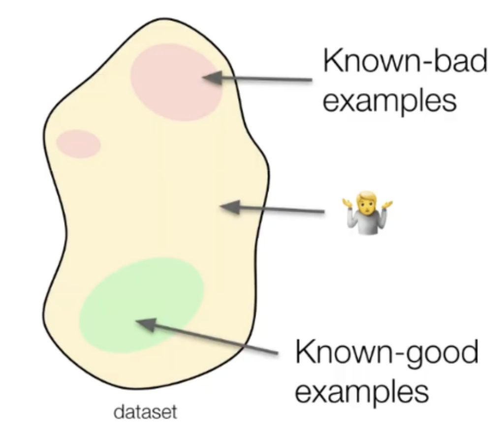

我们把这张图叫作“末日土豆”。We called this diagram "the potato of doom"

这看起来荒谬极了，到底是怎么回事？一个原因是，PDF 阅读器有动力尽可能多地解析各种文档。如果你收到一份 PDF 却打不开，你更可能责怪 PDF 阅读器，而不是生成这份文档的程序。为了避免这种情况，每个 PDF 阅读器都会尝试修复不符合标准的文档中的错误，而且各自的修复方式略有不同。同一份非标准文档，可能会被不同的 PDF 阅读器解释成两种不同的东西。This seems like an absurd situation, what’s going on? One reason for this is that PDF readers have an incentive to parse as many documents as possible. If you receive a PDF and it doesn’t open, you’re likely to blame the PDF reader, and not the program that created the document. To avoid this, every PDF reader tries to fix up mistakes in non-standard documents, and all of them do it slightly differently. The same non-standard document might get interpreted two different ways by different PDF readers.

写下这些话时，我感觉自己像雅克·德里达，但结论就是：*PDF 并不存在*——至少，它并不是一个可以被形式化的、边界分明的类别。相反，这里存在着一条模糊边界，在边界附近，某个东西可能算 PDF，也可能不算。这本来未必是什么大问题，偏偏现实中相当大一部分 PDF 就处在这个边界地带！I feel like Jacques Derrida writing this, but the result is that *PDF does not exist*, at least in the sense of a discrete category that can be formalized. Instead, there’s a fuzzy boundary where something might or might not be considered a PDF. That wouldn’t be so bad, except that a large proportion of actual PDFs exist in this liminal region!

解析器 1 · 解析器 2 · 标准

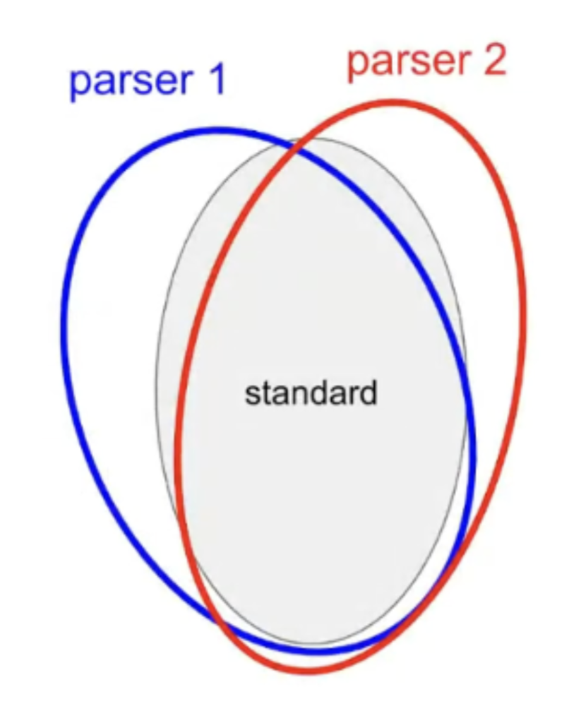

在 [DARPA SafeDocs 项目](https://www.darpa.mil/research/programs/safe-documents)中，Galois 花了数年时间尝试将 PDF 形式化。我们与 PDF 协会密切合作，使用了专为此目的开发的新语言 [DaeDaLus](https://github.com/GaloisInc/daedalus)。我为我们所做的工作感到自豪，但在项目结束时，我们的 PDF 形式化规格既不具备描述性——它与真实 PDF 阅读器的行为不同，也不具备规范性——它无法刻画我们认为正确的行为。而且，怎样才能得到一份更严谨、也更受认可的规格，仍然不清楚。On the [DARPA SafeDocs project](https://www.darpa.mil/research/programs/safe-documents), Galois spent several years working on formalizing PDF. We worked closely with the PDF Association using a new language we built for the purpose, [DaeDaLus](https://github.com/GaloisInc/daedalus). I’m proud of the work we did, but at the end of the project, our formal PDF specification was non-descriptive (it differs from real PDF readers), non-normative (it doesn’t characterize what we think should be correct behavior), and it’s unclear how to get to a more rigorous and accepted specification.

你可以在[这里](https://doi.ieeecomputersociety.org/10.1109/SPW54247.2022.9833889)阅读 Galois 关于 PDF 的工作，也可以在[这里](https://dl.acm.org/doi/10.1145/3656410)了解 DaeDaLus——我们为了帮助描述文档格式而构建的语言。You can read about Galois’s work on PDF [here](https://doi.ieeecomputersociety.org/10.1109/SPW54247.2022.9833889), and you can read about DaeDaLus, the language we built to help describe document formats, [here](https://dl.acm.org/doi/10.1145/3656410).

## *结论：*按我的意思做*Conclusion:* Do What I Mean

“你永远找不到一种编程语言，能免除你澄清自己想法的负担。”

“可我知道我想表达什么！”

[figure not shown]

[xkcd 第 568 篇。](https://xkcd.com/568/)许可协议：CC BY-NC 2.5[xkcd 568.](https://xkcd.com/568/) license: CC BY-NC 2.5

好，再讲一个故事：在当今这个形式化验证的时代，占据主导地位的始终是*证明*的成本。规格退居其次——我们连规格简单的系统都还验证不了，何必担心其他东西？如今，得益于[现代 AI 的进步](https://www.galois.com/articles/o3-frontier-math-and-the-future-of-mathematics)，我们可能很快就会进入一个奇妙的世界：证明既便宜又充裕。如果真是这样，我想我们会很快验证完所有编译器和微内核，然后发现自己再也前进不了了。就连 Claude 也无法告诉我们，我们究竟应该想要什么。Okay here’s another story: the current era of formal verification has been dominated by the cost of *proof*. Specification has taken second place—we can’t even verify systems with simple specs, so why worry about everything else? Now, thanks to [advances in modern AI](https://www.galois.com/articles/o3-frontier-math-and-the-future-of-mathematics), we may soon live in a strange world where proofs are cheap and abundant. If that happens, I think we will quickly verify every compiler and microkernel, then find that we’re stuck. Even Claude can’t tell us what to want.

今天的形式化验证非常有用，但对于大多数系统而言，很难写出验证所需要的那种*完整*规格。不过，其他类型的规格很受欢迎：例如，一个测试用例就是一种受限的、局部的规格。关键在于，测试用例立刻就能发挥作用，也不会给开发团队带来过高的成本。我们需要找到具备这些优点的系统规格描述方式，避免掉进一个陷阱：强行要求一种根本不存在的、完整而自洽的整体认识。Formal verification today is very useful, but for most systems it’s very difficult to write the kinds of *complete* specifications that verification needs. However, other kinds of specifications are popular: for example, a test case is a kind of limited, partial specification. The key is that a test case is immediately useful, and doesn’t impose undue costs on the development team. We need to find ways to specify systems that have these virtues, and avoid the trap of imposing a complete and coherent view that fundamentally does not exist.

形式化验证领域有一句老话：编写规格的过程，往往就能发现系统中的大多数缺陷。在我看来，这说明规格与*编程*之间存在一种相似性——它们都是表达我们想要什么的工具。从一个角度看，这个想法有些悲观：没有任何工具能够免除我们澄清想法的责任。但它也给了我一些希望。编程非常困难，但通过精心设计工具，我们已经让数亿人能够编程。只要有足够的运气和本领，也许我们能让规格也做到这一点。It’s a formal verification cliché that writing the specification tends to uncover most of the bugs in a system. To me, this suggests an analogy between specification and *programming*—both are tools for expressing what we want. In one way, this is a pessimistic thought: no tool can remove the burden of clarifying our ideas. But also, it gives me some hope. Programming is very difficult, but through careful tool design, we’ve made it available to hundreds of millions of people. With luck and skill, perhaps we can do the same for specifications.

我们才刚刚起步。还有很多事情要做。而且，我们还得留神那些外星人。We’re just getting started. There’s a lot to do. And we need to keep our eye out for those aliens.

1 不包括那个经济学的冒牌奖项。1 Not the fake one for Economics

2 我不想低估发明现有规格技术所付出的努力。所谓天然适合编写规格的系统，也只是*在今天的规格工具之下*才如此；这些工具凝聚了半个世纪的共同努力。2 I don’t want to undersell the work it took to invent the specification technologies we have now. The systems that are naturally specifiable are only so *with the specification tools of today*, which represent half a century of concerted work

3 你会说：啊哈，我们应该坚持要求工程师在构建每一个系统时，都*从*严格的形式化规格*开始*。在大多数情况下，我怀疑这种做法能否通过[成本／收益检验](https://www.galois.com/articles/what-works-and-doesnt-selling-formal-methods)。3 Ah-ha, you say, what we should do is insist that engineers build every system *starting* with a rigorous formal specification. In most cases, I’m skeptical this would pass the [cost/benefit test](https://www.galois.com/articles/what-works-and-doesnt-selling-formal-methods)

4 谨向让·鲍德里亚致以最诚挚的歉意。4 Avec toutes mes excuses à Jean Baudrillard